# lab5

Ethan Wanlass

11/14/2019

## Background

“This data consist of 19 variables on 403 subjects who were interviewed in a study to understand the prevalence of obesity, diabetes, and other cardiovascular risk factors in central Virginia for African Americans,” Lyanna Chu

## Processing the Data

First step to analyzing this data set was to clean the dat. THis involved getting rid of NA value and dropping factors that were not used. Additionally, we removed id, bp.2s and bp.2d as we do not need this variables. We put this all into our clean dataset diabetes_clean.

```r
library(dplyr)
```

```r
library(tidyr)
library(ggplot2)

diabetes = read.table('diabetes.txt',header=TRUE)
head(diabetes)
```

```
##     id chol stab.glu hdl ratio glyhb   location age gender height weight
## 1 1000  203       82  56   3.6  4.31 Buckingham  46 female     62    121
## 2 1001  165       97  24   6.9  4.44 Buckingham  29 female     64    218
## 3 1002  228       92  37   6.2  4.64 Buckingham  58 female     61    256
## 4 1003   78       93  12   6.5  4.63 Buckingham  67   male     67    119
## 5 1005  249       90  28   8.9  7.72 Buckingham  64   male     68    183
## 6 1008  248       94  69   3.6  4.81 Buckingham  34   male     71    190
##    frame bp.1s bp.1d bp.2s bp.2d waist hip time.ppn
## 1 medium   118    59    NA    NA    29  38      720
## 2  large   112    68    NA    NA    46  48      360
## 3  large   190    92   185    92    49  57      180
## 4  large   110    50    NA    NA    33  38      480
## 5 medium   138    80    NA    NA    44  41      300
## 6  large   132    86    NA    NA    36  42      195
```

```r
str(diabetes)
```

```
## 'data.frame':    403 obs. of  19 variables:
##  $ id      : int  1000 1001 1002 1003 1005 1008 1011 1015 1016 1022 ...
##  $ chol    : int  203 165 228 78 249 248 195 227 177 263 ...
##  $ stab.glu: int  82 97 92 93 90 94 92 75 87 89 ...
##  $ hdl     : int  56 24 37 12 28 69 41 44 49 40 ...
##  $ ratio   : num  3.6 6.9 6.2 6.5 8.9 ...
##  $ glyhb   : num  4.31 4.44 4.64 4.63 7.72 ...
##  $ location: Factor w/ 2 levels "Buckingham","Louisa": 1 1 1 1 1 1 1 1 1 1 ...
##  $ age     : int  46 29 58 67 64 34 30 37 45 55 ...
##  $ gender  : Factor w/ 2 levels "female","male": 1 1 1 2 2 2 2 2 2 1 ...
##  $ height  : int  62 64 61 67 68 71 69 59 69 63 ...
##  $ weight  : int  121 218 256 119 183 190 191 170 166 202 ...
##  $ frame   : Factor w/ 4 levels "","large","medium",..: 3 2 2 2 3 2 3 3 2 4 ...
##  $ bp.1s   : int  118 112 190 110 138 132 161 NA 160 108 ...
##  $ bp.1d   : int  59 68 92 50 80 86 112 NA 80 72 ...
##  $ bp.2s   : int  NA NA 185 NA NA NA 161 NA 128 NA ...
##  $ bp.2d   : int  NA NA 92 NA NA NA 112 NA 86 NA ...
##  $ waist   : int  29 46 49 33 44 36 46 34 34 45 ...
##  $ hip     : int  38 48 57 38 41 42 49 39 40 50 ...
##  $ time.ppn: int  720 360 180 480 300 195 720 1020 300 240 ...
```

```r
diabetes[diabetes == '']= NA
table(diabetes == '')
```

```
##
## FALSE
##  7082
```

```r
diabetes$frame = droplevels(diabetes$frame)
diabetes$location = droplevels(diabetes$location)
diabetes$gender = droplevels(diabetes$gender)

diabetes_reduced = diabetes %>% select(-id,-bp.2s,-bp.2d)
str(diabetes_reduced)
```

```
## 'data.frame':    403 obs. of  16 variables:
##  $ chol    : int  203 165 228 78 249 248 195 227 177 263 ...
##  $ stab.glu: int  82 97 92 93 90 94 92 75 87 89 ...
##  $ hdl     : int  56 24 37 12 28 69 41 44 49 40 ...
##  $ ratio   : num  3.6 6.9 6.2 6.5 8.9 ...
##  $ glyhb   : num  4.31 4.44 4.64 4.63 7.72 ...
##  $ location: Factor w/ 2 levels "Buckingham","Louisa": 1 1 1 1 1 1 1 1 1 1 ...
##  $ age     : int  46 29 58 67 64 34 30 37 45 55 ...
##  $ gender  : Factor w/ 2 levels "female","male": 1 1 1 2 2 2 2 2 2 1 ...
##  $ height  : int  62 64 61 67 68 71 69 59 69 63 ...
##  $ weight  : int  121 218 256 119 183 190 191 170 166 202 ...
##  $ frame   : Factor w/ 3 levels "large","medium",..: 2 1 1 1 2 1 2 2 1 3 ...
##  $ bp.1s   : int  118 112 190 110 138 132 161 NA 160 108 ...
##  $ bp.1d   : int  59 68 92 50 80 86 112 NA 80 72 ...
##  $ waist   : int  29 46 49 33 44 36 46 34 34 45 ...
##  $ hip     : int  38 48 57 38 41 42 49 39 40 50 ...
##  $ time.ppn: int  720 360 180 480 300 195 720 1020 300 240 ...
```

```r
index.na=apply(is.na(diabetes_reduced), 1, any)
table(index.na)
```

```
## index.na
## FALSE  TRUE
##   366    37
```

```r
diabetes_clean = diabetes_reduced[-which(index.na),]
index.na=apply(is.na(diabetes_clean), 1, any)
table(index.na)
```

```
## index.na
## FALSE
##   366
```

## Exploring the data

Our variable of interest is glyhb (Glycosolated Hemoglobin). However, before we can explore this value we needed to clean it. Checking the first distribution we can see that the distribution is right skewed. Thus, we took the log to even it out a bit. Checking that distribution we can still see that it’s still right skewed. Thus, we took out some of the outliers by removing values that were 1.5 times outside the inner quartile range from the first and third quartile. Finally, checking the distribution we can see it looks much more symmetric.

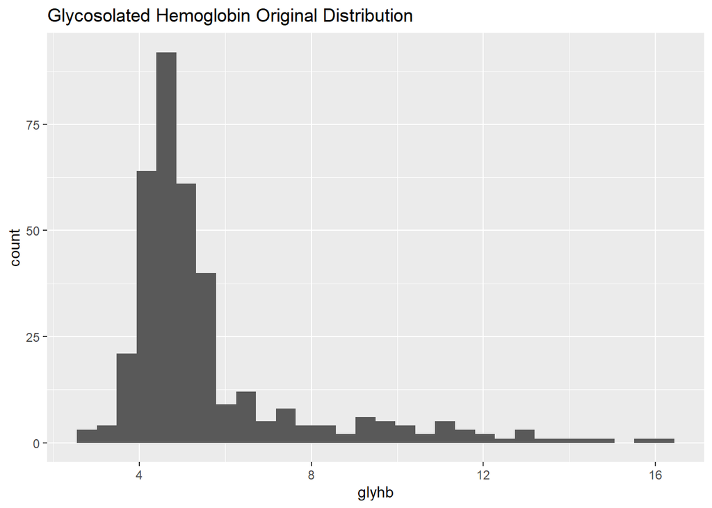

```r
ggplot(diabetes_clean, aes(glyhb)) + geom_histogram() + labs(title = "Glycosolated Hemoglobin Original Distribution")
```

```r
summary(diabetes_clean$glyhb)
```

```
##    Min. 1st Qu.  Median    Mean 3rd Qu.    Max.
##   2.680   4.393   4.860   5.607   5.630  16.110
```

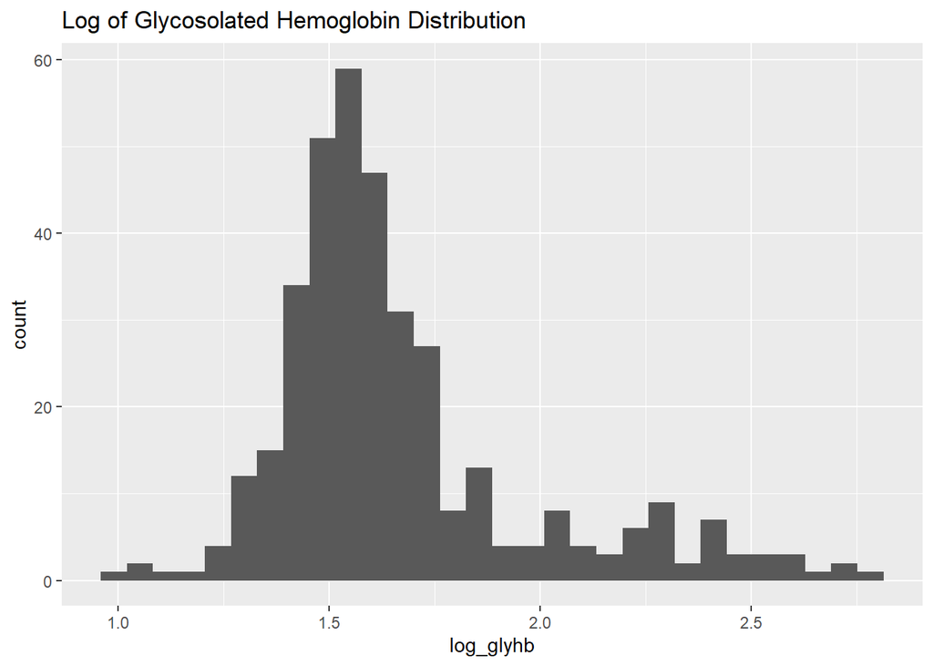

```r
diabetes_clean = diabetes_clean %>% mutate(log_glyhb = log(glyhb))
ggplot(diabetes_clean, aes(log_glyhb)) + geom_histogram() + labs(title = "Log of Glycosolated Hemoglobin Distribution")
```

```r
first_quartile = summary(diabetes_clean$log_glyhb)[["1st Qu."]]
third_quartile = summary(diabetes_clean$log_glyhb)[["3rd Qu."]]
IQR = third_quartile - first_quartile
glyhb_star = diabetes_clean %>% filter(log_glyhb >= (first_quartile - 1.5*IQR) & log_glyhb<= (third_quartile + 1.5*IQR))
class(glyhb_star)
```

```
## [1] "data.frame"
```

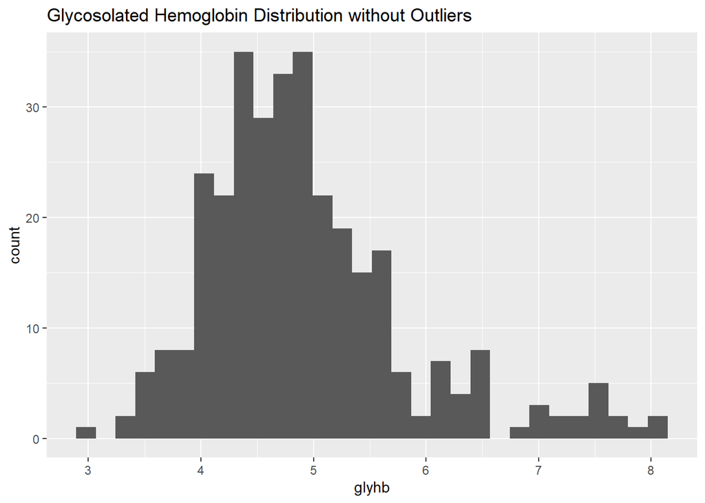

```r
ggplot(glyhb_star, aes(glyhb)) + geom_histogram() + labs(title = "Glycosolated Hemoglobin Distribution without Outliers")
```